# Import and plot spline data from AAA

Stefano Coretta

2017-06-10

The package `rticulate` facilitates UTI data import and plotting with spline data exported from Articulate Assistant Advanced (AAA). To use the package, load it as usual.

```r
library(rticulate)
```

# Import spline data

To correctly import AAA data, it is required that the file exported from AAA does not contain the header. This must be supplied as an argument to the `read_aaa()` function. We thus create a character vector with a concatenation of column names as strings.

```r
columns <- c(
    "speaker",
    "seconds",
    "rec.date",
    "prompt",
    "label",
    "TT.displacement.sm",
    "TT.velocity",
    "TT.velocity.abs",
    "TD.displacement.sm",
    "TD.velocity",
    "TD.velocity.abs"
)
```

Now we can use `read_aaa()` to import the spline data as a tibble. The function requires a string with the file path and name, and a vector with the names of the columns.

```r
# system.file() is needed here because the example files reside in the package.
# You can just include the file path directly in read_aaa, like
# read_aaa("~/Desktop/splines.tsv", columns)
file.path <- system.file("extdata", "sc01-aaa.tsv", package = "rticulate")

tongue <- read_aaa(file.path, columns)
```

To check the head of the tibble, just do:

```r
tongue
```

```
## # A tibble: 4,578 x 14
##    speaker seconds            rec.date               prompt    label
##  *   <chr>   <dbl>               <chr>                <chr>    <chr>
##  1    sc01  1.6305 29/11/2016 15:10:47 Dico pugu lentamente   max_TD
##  2    sc01  1.6250 29/11/2016 15:10:47 Dico pugu lentamente  NONS_TD
##  3    sc01  1.5745 29/11/2016 15:10:47 Dico pugu lentamente peak1_TD
##  4    sc01  1.5745 29/11/2016 15:10:47 Dico pugu lentamente peak2_TD
##  5    sc01  1.1115 29/11/2016 15:10:52 Dico pada lentamente   max_TT
##  6    sc01  1.1160 29/11/2016 15:10:52 Dico pada lentamente  NOFF_TT
##  7    sc01  1.1020 29/11/2016 15:10:52 Dico pada lentamente  NONS_TT
##  8    sc01  1.0485 29/11/2016 15:10:52 Dico pada lentamente peak1_TT
##  9    sc01  1.1485 29/11/2016 15:10:52 Dico pada lentamente peak2_TT
## 10    sc01  1.3145 29/11/2016 15:10:57 Dico poco lentamente   max_TD
## # ... with 4,568 more rows, and 9 more variables:
## #   TT.displacement.sm <dbl>, TT.velocity <dbl>, TT.velocity.abs <dbl>,
## #   TD.displacement.sm <dbl>, TD.velocity <dbl>, TD.velocity.abs <dbl>,
## #   fan <int>, X <dbl>, Y <dbl>
```

Sometimes is useful to add extra information for each prompt (like vowel, consonant place, phonation, etc.). We can do so by using functions from the `dplyr` package (`word()` is from the `stringr` package).

```r
nonce <- read_csv(system.file("extdata", "nonce.csv", package = "rticulate"))
tongue <- mutate(tongue, word = stringr::word(prompt, 2)) %>%
    left_join(y = nonce) %>%
    mutate_if(is.character, as.factor)
```

Let’s check `tongue` again.

```r
tongue
```

```
## # A tibble: 4,578 x 25
##    speaker seconds            rec.date               prompt    label
##     <fctr>   <dbl>              <fctr>               <fctr>   <fctr>
##  1    sc01  1.6305 29/11/2016 15:10:47 Dico pugu lentamente   max_TD
##  2    sc01  1.6250 29/11/2016 15:10:47 Dico pugu lentamente  NONS_TD
##  3    sc01  1.5745 29/11/2016 15:10:47 Dico pugu lentamente peak1_TD
##  4    sc01  1.5745 29/11/2016 15:10:47 Dico pugu lentamente peak2_TD
##  5    sc01  1.1115 29/11/2016 15:10:52 Dico pada lentamente   max_TT
##  6    sc01  1.1160 29/11/2016 15:10:52 Dico pada lentamente  NOFF_TT
##  7    sc01  1.1020 29/11/2016 15:10:52 Dico pada lentamente  NONS_TT
##  8    sc01  1.0485 29/11/2016 15:10:52 Dico pada lentamente peak1_TT
##  9    sc01  1.1485 29/11/2016 15:10:52 Dico pada lentamente peak2_TT
## 10    sc01  1.3145 29/11/2016 15:10:57 Dico poco lentamente   max_TD
## # ... with 4,568 more rows, and 20 more variables:
## #   TT.displacement.sm <dbl>, TT.velocity <dbl>, TT.velocity.abs <dbl>,
## #   TD.displacement.sm <dbl>, TD.velocity <dbl>, TD.velocity.abs <dbl>,
## #   fan <int>, X <dbl>, Y <dbl>, word <fctr>, item <int>, ipa <fctr>,
## #   c1 <fctr>, c1phonation <fctr>, vowel <fctr>, anteropost <fctr>,
## #   height <fctr>, c2 <fctr>, c2phonation <fctr>, c2place <fctr>
```

# Plot splines

To plot splines from a spline data frame, use `plot_splines()`. This function is a wrapper of a `ggplot` call (from the `ggplot2` package). The coordinates must be in two variables named `X` and `Y`. `read_aaa()` creates them automatically while importing the raw data.

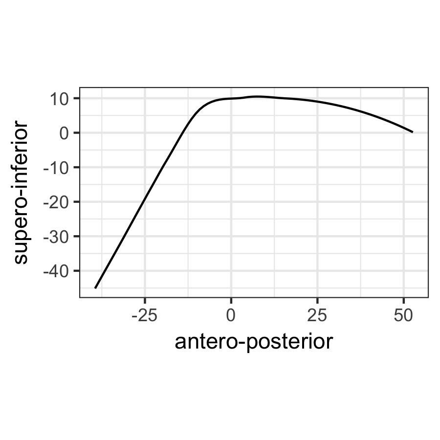

```r
plot_splines(tongue)
```

You can also easily filter the tibble with the `filter()` function from `dplyr`.

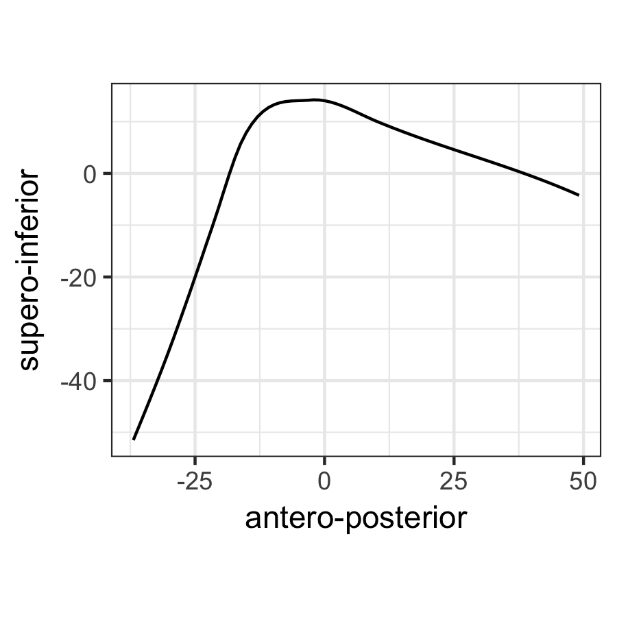

```r
filter(tongue, label == "max_TD") %>%
    plot_splines()
```

You can specify `geom` options and aesthetics in the usual `ggplot` way (remember to load the package with `library(ggplot2)` if you need this). `geom` options are arguments of `plot_splines()`, while aesthetics can be called with `aes()`.

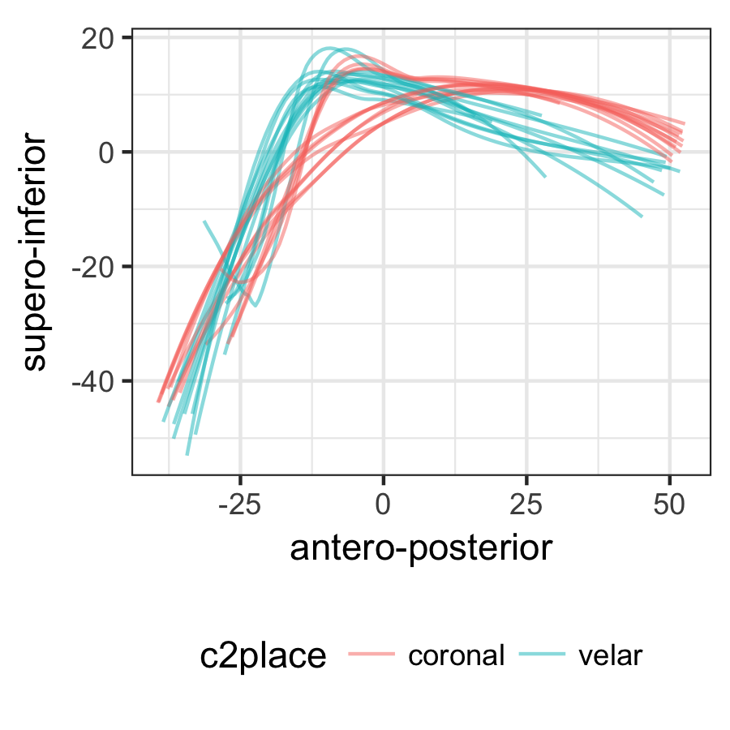

```r
plot_splines(tongue, alpha = 0.5) +
    aes(group = rec.date, colour = c2place) +
    theme(legend.position="bottom")
```

Finally, if you want to plot the palate profile, you can do so by specifying a data frame with the coordinates for the palate spline.

```r
palate <- read_aaa(system.file("extdata", "sc01-palate.tsv", package = "rticulate"), columns)
```

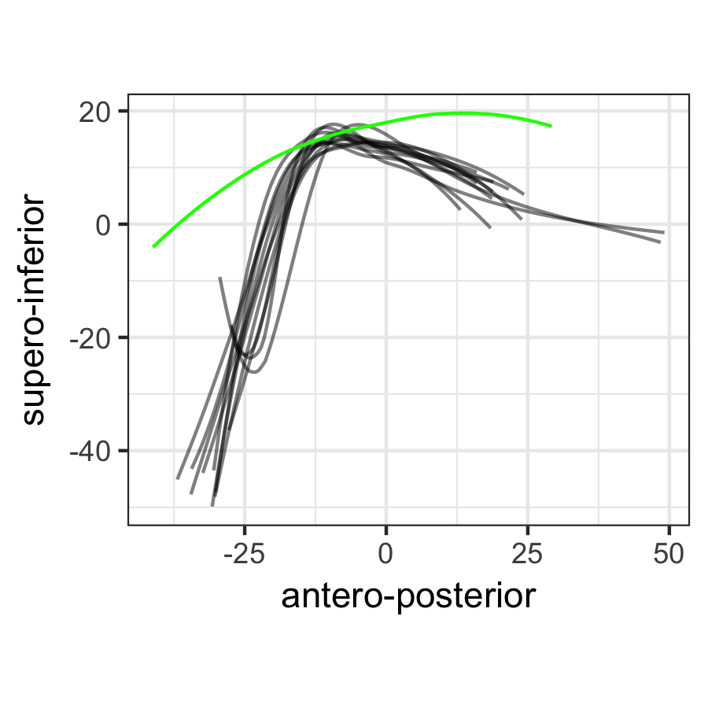

```r
filter(tongue, label == "max_TD") %>%
    plot_splines(palate = palate, alpha = 0.5) + aes(group = rec.date)
```